# World Series

Ty Painter

September 24, 2020

# 1 Introduction

In this blog, I will perform different calculations based on various probabilities and discrete probabilities to examine the affect of the win probability of a head-to-head matchup has over a multiple game series.

## 1.1 Background

The World Series is a best-of-7 game series between the champions from the American and National League. A best-of-7 game series designates the first team to win 4 games as the winner of the series. I will use the rules of probability and discrete probability to calculate the probabilities related to winning the World Series. In my scenario, the Braves (National League Champion) and the Yankees (American League Champion) will be competing for the World Series. The probability of the Braves winning an individual game will be represented by $P_B$ and the probability of the Yankees winning an individual game will be represented by $P_Y$ = 1 - $P_B$.

# 2 Methods

## 2.1 Question 1

```r
# probability of the Braves losing 3 or fewer games, before winning 4 games, with a win probability of .55
pnbinom(3, 4, .55)
```

```
## [1] 0.6082878
```

I used pnbinom() to calculate the probability of the Braves winning 4 games while losing 3 or fewer games, with a individual head-to-head winning probability of 0.55.

## 2.2 Question 2

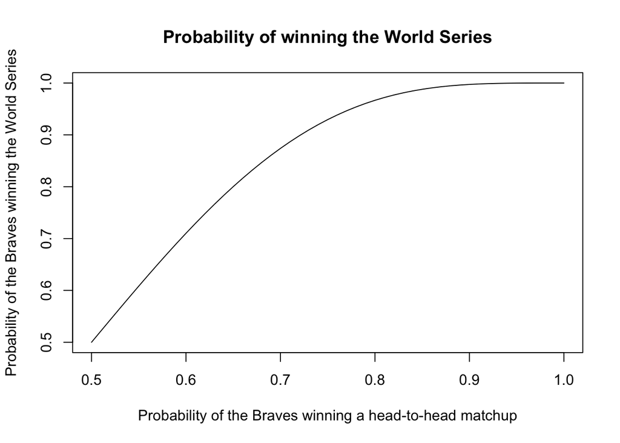

```r
head_2_head <- seq(from = .5, to = 1, .01) # sequence of head to head win probabilities
win_ws <- rep(0, 51) # create initial probability of winning World Series

for(i in 1:length(head_2_head)) {
  # find the probability of winning the World Series based on each head to head win probability
  win_ws[i] = pnbinom(3, 4, head_2_head[i])
}
# plot results
plot(x = head_2_head, y = win_ws, type = 'l',
     xlab = 'Probability of the Braves winning a head-to-head matchup',
     ylab = 'Probability of the Braves winning the World Series',
     main = 'Probability of winning the World Series')
```

In the graph above I calculated the probability of the Braves winning the World Series given the Braves have a certain head-to-head winning percentage ranging from 0.5 to 1.

## 2.3 Question 3

```r
wins_needed <- 0 # initiate wins needed to end the series variable
world_series_prob <- 0 # initiate probability of winning the WS variable
# calculate how many wins are needed to make the winning the WS probability over .8
while(world_series_prob < .8){
  wins_needed = wins_needed + 1
  world_series_prob = pnbinom(wins_needed - 1, wins_needed, .55)
}
series_length <- wins_needed + (wins_needed - 1) # calculate series length by adding wins and losses (wins_needed -1)
series_length
```

```
## [1] 71
```

For the Braves to achieve a World Series win probability over 0.8 with a head-to-head win probability of 0.55, they would need to play a best-of-71 game series. They would have to win 36 games (wins_needed) and could lose no more than 35 games (wins_needed - 1)

## 2.4 Question 4

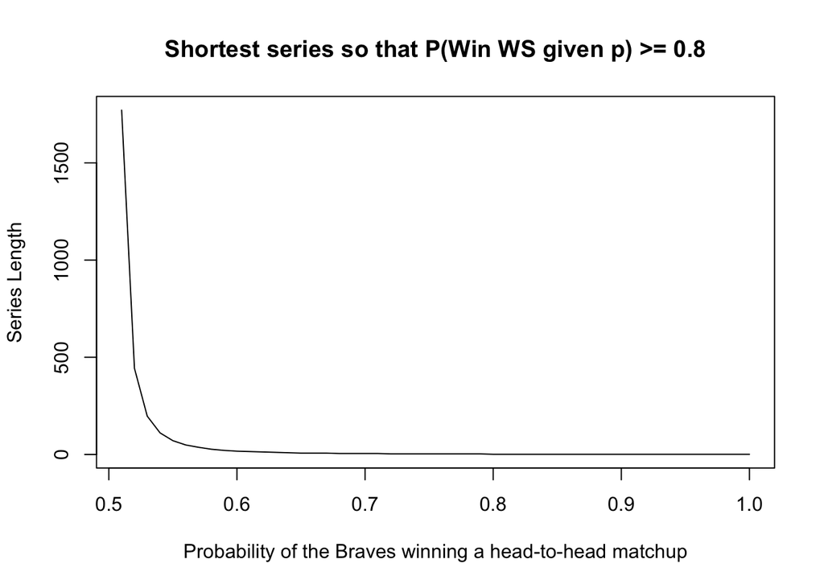

```r
xhead_2_head <- seq(from = .51, to = 1, .01) # sequence of head to head win probabilities
xworld_series_prob <- rep(0, 50) # initiate blank vector for probability of winning the WS variable
xseries_length <- rep(0, 50) # initiate blank vector for series length variable
# calculate the shortest length of a series needed for various head-to-head win probabilities
for(i in 1:length(xhead_2_head)) {
  xwins_needed = 0
  while(xworld_series_prob[i] < .8) {
    xwins_needed = xwins_needed + 1
    xworld_series_prob[i] = pnbinom(xwins_needed - 1, xwins_needed, xhead_2_head[i])
  }
  xseries_length[i] <- xwins_needed + (xwins_needed - 1)
}
# plot results
plot(x = xhead_2_head, y = xseries_length, type ='l',
     xlab = 'Probability of the Braves winning a head-to-head matchup',
     ylab = 'Series Length',
     main = 'Shortest series so that P(Win WS given p) >= 0.8')
```

In the graph above, I found the shortest series of games that the Yankees and Braves would have to play, based on the Braves head-to-head win probability, to ensure the Braves probability of winning the World Series is 0.8.

## 2.5 Question 5

I used Bayes Theorem to calculate P($P_B$ = 0.55 | Braves win WS in 7 games), under the assumption that $P_B$ = 0.45 or 0.55. I assumed the each win probability would be have an equal chance of being used so each marginal row probability would be 0.5. I then used dnbinom(3, 4, $P_B$) to calculate the row probabilities for $P_B$ = 0.55 and 0.45. I then multiplied the row probabilities of $P_B$ = 0.55 (.1668) and $P_B$ = 0.45 (.1364) by the each row marginal probability of 0.5. This result in the cell probabilities of P($P_B$ = 0.55 & Braves win WS in 7 games) = .0834 and P($P_B$ = 0.45 & Braves win WS in 7 games) = .0682. I added these cell probabilities together to find the column marginal probability for P(Braves win WS in 7 games) = .1516. Now to find the P($P_B$ = 0.55 | Braves win WS in 7 games), I divided the P($P_B$ = 0.55 & Braves win WS in 7 games) by the marginal probability for P(Braves win WS in 7 games) to calculate ($\frac{.0834} {.1516}$) the P($P_B$ = 0.55 | Braves win WS in 7 games) = .5501.

# 3 Conclusions

The conclusions I made were strictly from the two graphs displayed above. The probability of winning the World Series based on the probability of winning a head-to-head matchup seems to flatten out when the probability of winning a head-to-head matchup is at least 0.8. From this I conclude that the probability of winning the World Series remains similar with a head-to-head win probability that is at least 0.8. For the other graph, the length of a series decreases significantly when the head-to-head win probability increases from 0.5 to 0.6, the the curve flattens out with anything greater than 0.6 I concluded that a head-to-head win proability that is at least 0.6 dramatically reduces the length of a series.